# Formal Modeling of Psychological Processes

PSYC470

Methods & Computing for the Psychological Sciences: From Data to Discovery

November 20, 2025

# Why Formal Models?

- Move from **description** (e.g., regression associations) to **mechanism**.
- Make **testable commitments** (Popper: models should risk being wrong).
- Produce **quantitative predictions** we can plot and compare against data.
- Is Gravity real?
  $$F=G*\frac{m_1*m_2}{r^2}$$

# Falsifiability

Core principle of scientific inquiry, championed by the philosopher Karl Popper

Science does not advance by trying to prove a theory is right. Science advances by trying, relentlessly, to prove a theory is wrong.

If your hypothesis cannot, in principle, be proven false, it is not a scientific theory; it is a belief system.

# Models in Physics

*Natural‑language model*: Isaac Newton’s “General Theory of Pushing Stuff.”

- When you push an object, it tends to go in the direction you pushed it.
- If the object is really heavy, it won’t go very fast, but if it’s light, it will zoom away quite quickly. - Also, things generally stop eventually unless they are in space, where they tend to float on for a while.

Equipped with this knowledge, NASA engineers set out to land a rocket on Mars

# Models in Psychology

*Natural‑language model*: “People learn more about things when the outcome is surprising, and learn less when outcomes are expected.”

**The Problem of “Hidden Parameters”** Natural language is inherently ambiguous and open to interpretation.

This makes the theory nearly impossible to disprove. If the data shows a tiny increase, the theorist says, “See? It went up.” If the data shows a massive increase, they say, “See? It went up.” The model is too flexible to be useful for scientific purposes.

# Models in Psychology

Formal models work by forcing researchers to expose their “hidden parameters.”

- Committing to an equation (e.g., $\text{Prediction Error} = \text{Outcome} - \text{Expectation}$), removes the ambiguity.
- If the model predicts a value of +10 and the data shows +50, the model is wrong.
- There is no debating what the word “increase” meant.
- This clarity is the *only* way to move a field from arguing over semantics to improving understanding.

# Error-Driven Learning (Rescorla-Wagner)

The Rescorla-Wagner (R-W) model is arguably the most influential formal model of associative learning.

The model formalizes the relationship between a set of cues (Conditioned Stimuli, CS) and an outcome (Unconditioned Stimulus, US). - It tracks the “associative strength” ($V$) for each cue, which represents how strongly that cue is associated with (i.e., predicts) the outcome.

# Building the Rescorla-Wagner (R-W) Model

The first step is to identify the relevant parameters from the natural-language theory. For example:

1. I can’t really learn anything about something if it’s not important to me or I’m not paying attention to it, so at least one parameter that contributes to learning must be related to the salience of the stimulus.
2. Some people learn things faster than others and I can learn things faster if I’m super motivated, so we must also need a variable related to how quickly the learning happens…the learning rate.
3. If I learn something like “gray clouds means I can expect rain”, but one day I see gray clouds and it doesn’t rain, then I would probably adjust my thinking/learning, so there should be some parameter to represent how an event is different from expectations. Maybe we could call this “prediction error”.

# Build a Formal Representation

- Cues ($i$) are **present/absent** each trial ($t$): $x_{i,t} \in {0,1}$
- Outcome ($\lambda$) can be **present/absent** each trial: $\lambda_t \in {0,1}$
- Association ($V$) between Cue $i$ and the outcome on any given trial: $0 \leq V_{i,t} \leq 1$
- Cue Salience: $\alpha > 0$
- Learning Rate: $\beta > 0$
- Prediction: $E_t = \sum_i V_{i,t},x_{i,t}$
- Prediction error: $\delta_t = \lambda_t - E_t\\$ where $\lambda_t$ is the outcome (e.g., Food: 1/0)
- Update (“learning”): $\Delta V_{i,t} = \alpha_i * \beta * \delta_t$

# Run the Simulation

We stated above that events would be represented by zeros and ones to represent their absence or presence on any given trial.

This is illustrated in the table below, showing *n* trials of pairing a light with food.

| Trial | Light | Bell | Food |
| --- | --- | --- | --- |
| 1 | 1 | 0 | 1 |
| 2 | 1 | 0 | 1 |
| 3 | 1 | 0 | 1 |
| 4 | 1 | 0 | 1 |
| 5 | 1 | 0 | 1 |
| . | . | . | . |
| . | . | . | . |
| . | . | . | . |
| *n* | 1 | 0 | 1 |

Now we need to represent the cognitive machinery specified by the model

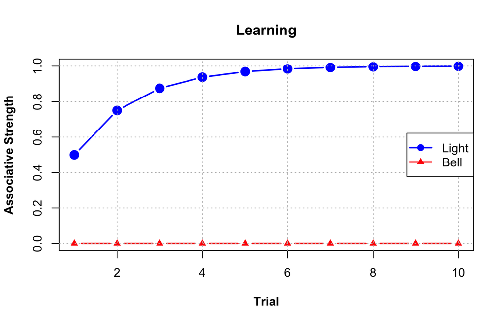

```r
# --- Establish Model Parameters ---
alpha_light <- 0.5  # Salience of the light cue
alpha_bell <- 0.5   # Salience of the bell cue
beta <- 1.0         # Learning rate for the food outcome

# --- Experiment Setup ---
V_light <- 0        # Associative strength for the light
V_bell <- 0         # Associative strength for the bell

# 10 Trials of Light and Food present
Trials <- data.frame(
  Light = c(1, 1, 1, 1, 1, 1, 1, 1, 1, 1),
  Bell  = c(0, 0, 0, 0, 0, 0, 0, 0, 0, 0),
  Food  = c(1, 1, 1, 1, 1, 1, 1, 1, 1, 1)
)

# Containers to Store results for plotting
light_strength_history <- c()
bell_strength_history <- c()

# --- Phase 1: Train the Light Alone ---
for (trial in 1:nrow(Trials)) {
  # Determine which stimuli are present
  light_present<-Trials$Light[trial]
  bell_present<-Trials$Bell[trial]
  # Determine whether food was present
  lambda<-Trials$Food[trial]
  # Expectation is the sum of strengths ONLY for PRESENT cues
  total_expectation <- (V_light * light_present) + (V_bell * bell_present)

  # Calculate the "surprise" or prediction error
  prediction_error <- lambda - total_expectation

  # Update light strength
  delta_V_light <- alpha_light * beta * prediction_error * light_present
  V_light <- V_light + delta_V_light
  # Update bell strength
  delta_V_bell <- alpha_bell * beta * prediction_error * bell_present
  V_bell <- V_bell + delta_V_bell

  # Store current strengths
  light_strength_history <- c(light_strength_history, V_light)
  bell_strength_history <- c(bell_strength_history, V_bell)
}
```

# Making Predictions About New Situations

What happens if we now introduce a new stimulus alongside the one the model has already learned?

This scenario leads to one of the most famous and important phenomena in learning theory: the blocking effect.

# Implement the Experiment

```r
# Note that the model has already "learned" the association between the light and food above

# 10 Trials of Bell, Light and Food present
Trials <- data.frame(
  Light = c(1, 1, 1, 1, 1, 1, 1, 1, 1, 1),
  Bell  = c(1, 1, 1, 1, 1, 1, 1, 1, 1, 1),
  Food  = c(1, 1, 1, 1, 1, 1, 1, 1, 1, 1)
)

# The rest of the simulation is identical to the model above.
```

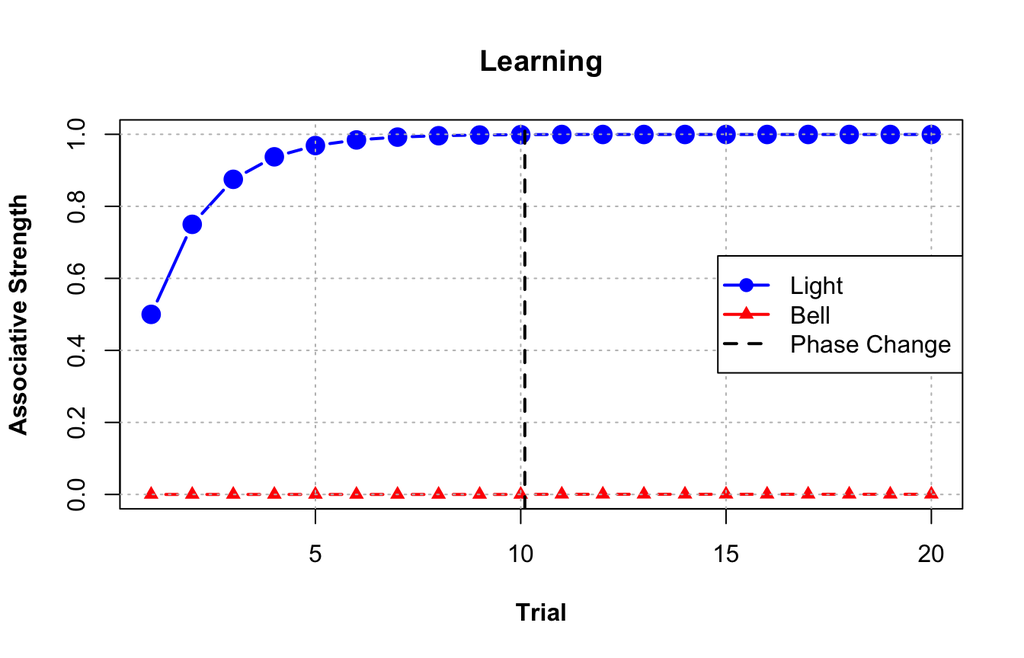

# Extinguishing Learning

Now let’s see what happens when the light no longer predicts the food.

```r
# Note that model has already been trained on the 20 trials described above

# 10 Trials of Bell, Light and Food present
Trials <- data.frame(
  Light = c(1, 1, 1, 1, 1, 1, 1, 1, 1, 1),
  Bell  = c(0, 0, 0, 0, 0, 0, 0, 0, 0, 0),
  Food  = c(0, 0, 0, 0, 0, 0, 0, 0, 0, 0)
)

# The rest of the simulation is identical to the model above.
```

As the learning about the light is extinguished, the model rapidly “forgets” the association between the light and the food.

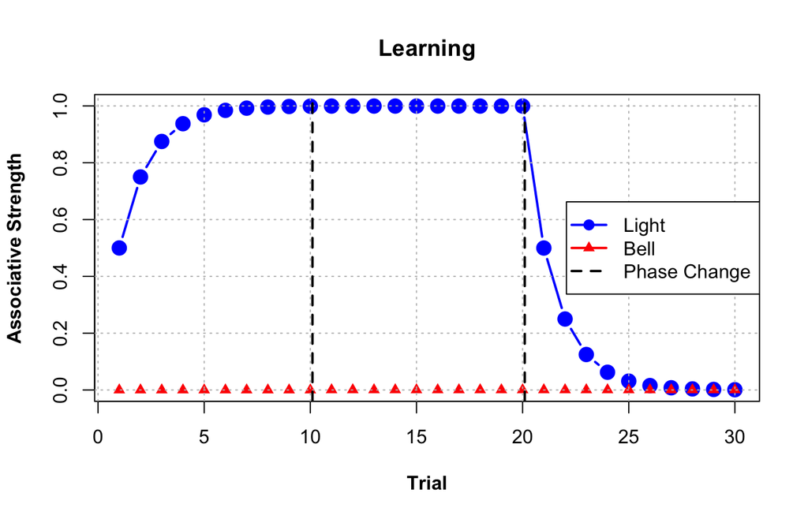

# Belief Updating: An Introduction to Bayesian Learning

Bayesian models offer a fundamentally different perspective on learning. Instead of tracking a single value like associative strength, The Bayesian model tracks its degree of “belief” about the world in the form of a probability distribution. Learning in this context is the process of updating these beliefs when new evidence is collected.

**The core of Bayesian inference lies in combining two sources of information:**

1. Prior Belief: What you believe about the world before observing new data. This can be strong (based on years of experience) or weak (a complete guess).
2. Likelihood: How likely is your new observation, given your current belief? This is the new evidence.

**Bayes’ Rule: The Engine of Belief Updating**

The mathematical engine that combines the prior and the likelihood is a simple but profound formula known as Bayes’ Rule.

It states that the posterior belief is proportional to the prior belief multiplied by the likelihood.

The full formula is:

$$P(H|E) =
\frac{P(E|H)*P(H)}{P(E)}$$
Where:

$P(H|E)$ - The Posterior: The probability of our Hypothesis $(H)$ being true, given the Evidence $(E)$ we just observed. This is what we want to calculate—our updated belief distribution.

$P(E|H)$ - The Likelihood: The probability of observing the Evidence if our Hypothesis were true. This is the part that connects our belief to the actual data.

$P(H)$ - The Prior: The probability of our Hypothesis being true before we saw any new evidence. This is our starting belief.

$P(E)$ - The Marginal Likelihood: The overall probability of observing the Evidence, averaged over all possible hypotheses. This is a normalizing constant that ensures the final posterior probabilities sum to 1.

# Implementation: The Beta-Binomial Model

Because it is a little more complex than the R-W model, let’s start with a simple example of Bayesian learning.

The classic example is flipping a coin and trying to figure out if it’s fair.

We want to estimate its “bias,” or the probability $(\theta)$ that it will land on heads. If you believe that probability is 0.5, then you believe that the coin is completely unbiased.

However, if you believe that probability is 0.75, then you believe that the coin is biased toward landing on heads.

Our belief about the coin’s bias can be represented by a Beta probability distribution. This distribution is flexible and is defined by two shape parameters, $\alpha$ and $\beta$. A flat $Beta(\alpha=1, \beta=1)$ represents a totally uncertain prior, while a sharply peaked $Beta(\alpha=5, \beta=5)$ represents a very strong belief that the coin is fair.

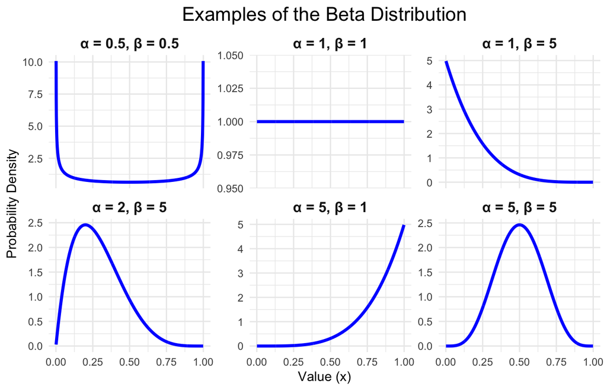

# Binary Outcomes Simplify the Math

This allows us to bypass the complex formula and use an incredibly simple update rule:

- heads_posterior = heads_prior + number_of_heads
- tails_posterior = tails_prior + number_of_tails

#Implementation

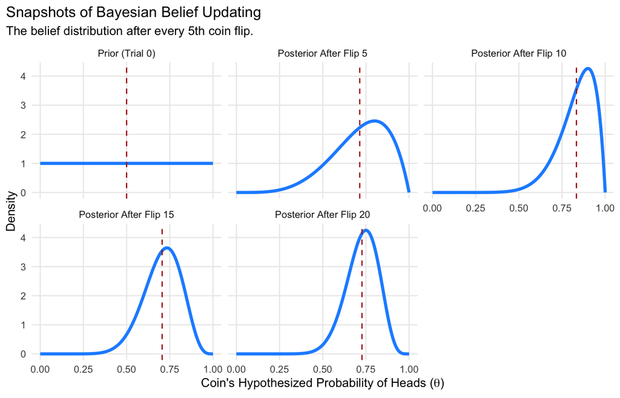

```r
# --- 1. Define the Prior Belief & Experiment ---
# We start with an uninformative prior, Beta(1,1).
initial_heads <- 1
initial_tails <- 1

# Create the same reproducible sequence of 20 flips with 15 heads.
set.seed(123) # for reproducibility
outcomes <- c(rep("Heads", 15), rep("Tails", 5))
coin_flips <- sample(outcomes) # Shuffle the outcomes

# --- 2. Loop Through Data and Record Belief History ---
# Generate the belief state after every single flip and store it.
history_list <- list()
current_heads <- initial_heads
current_tails <- initial_tails

for (i in 1:length(coin_flips)) {
  outcome <- coin_flips[i]
  if (outcome == "Heads") {
    current_heads <- current_heads + 1
  } else {
    current_tails <- current_tails + 1
  }

  history_list[[i]] <- data.frame(
    Flip_Number = i,
    nHeads = current_heads,
    nTails = current_tails
  )
}
# Combine the list into one data frame
history_data <- bind_rows(history_list)
```

# Bayesian Classical Conditioning

Now that we’ve had a chance to understand the basic premise of Bayesian belief updating, let’s consider the same classical conditioning situation that was learned by the Rescorla-Wagner model.

This time, we need to model two beliefs:

1. the probability that food will appear following the light ($Beta(\alpha_{light},\beta_{light})$)
2. the probability that food will appear following the bell ($Beta(\alpha_{bell},\beta_{bell})$).

Just like before, we can think of the $\alpha$ and $\beta$ parameters as a scoreboard.

- $\alpha_{light}$ = # times the light “successfully” predicts food
- $\beta_{light}$ = the count of failures (light appears but not food).

# Simulation

Expose model to the exact same experimental trials as the Rescorla-Wagner model.

Three blocks of ten trials.

- “acquisition” trials = light + food
- “compound” trials = light + bell + food
- “extinction” trials = light alone

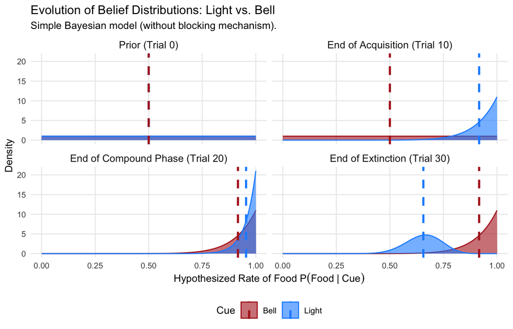

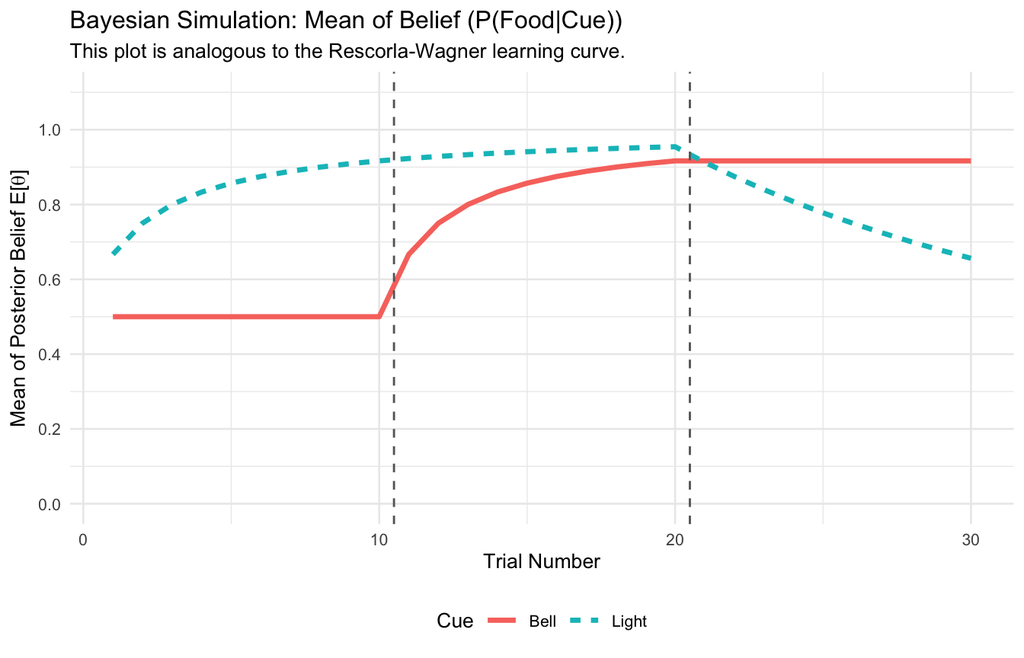

```r
# --- 1. Define the Priors (The "Prior" beliefs State) ---
# The model starts with a completely open mind (uninformative prior).
# We use a Beta(1,1) distribution, which is a flat line representing total uncertainty.
# We need a separate belief for each cue.
# 'a' represents "counts" of Food, 'b' represents "counts" of No Food.
a_light <- 1
b_light <- 1

a_bell <- 1
b_bell <- 1

# --- 2. Design the Experiment (The "Data") ---
# We use the EXACT same experimental plan as the Rescorla-Wagner model for direct comparison but with a slightly more intuitive setup.
phase1 <- data.frame(Trial = 1:10, Phase = "1. Acquisition", Light = 1, Bell = 0, Food = 1)
phase2 <- data.frame(Trial = 11:20, Phase = "2. Blocking", Light = 1, Bell = 1, Food = 1)
phase3 <- data.frame(Trial = 21:30, Phase = "3. Extinction", Light = 1, Bell = 0, Food = 0)
experiment_plan <- bind_rows(phase1, phase2, phase3)

# --- 3. Run the Simulation (The "Update" Process) ---
# We loop through each trial and update the parameters of our Beta distributions.
history <- data.frame()

for (i in 1:nrow(experiment_plan)) {
  current_trial <- experiment_plan[i, ]
  light_present <- current_trial$Light
  bell_present <- current_trial$Bell
  food_present <- current_trial$Food

  # Bayesian update depends on which cues are present
  if (light_present == 1 && bell_present == 0) { # Light alone
    a_light <- a_light + food_present
    b_light <- b_light + (1 - food_present)
  } else if (light_present == 0 && bell_present == 1) { # Bell alone (not in this experiment)
    a_bell <- a_bell + food_present
    b_bell <- b_bell + (1 - food_present)
  } else if (light_present == 1 && bell_present == 1) { # Compound trial (Light + Bell)
    a_light <- a_light + food_present
    b_light <- b_light + (1 - food_present)

    a_bell <- a_bell + food_present
    b_bell <- b_bell + (1 - food_present)
  }

  # Store the state (both the parameters and the mean of the belief)
  trial_history <- data.frame(
    Trial = current_trial$Trial,
    Phase = current_trial$Phase,
    a_light = a_light, b_light = b_light, mean_light = a_light / (a_light + b_light),
    a_bell = a_bell, b_bell = b_bell, mean_bell = a_bell / (a_bell + b_bell)
  )
  history <- bind_rows(history, trial_history)
}
```

# Head-to-Head: Key Differences

- **RW**: Learning driven by **prediction error**; blocking/extinction are natural consequences.
- **Bayesian**: Learning driven by **evidence accumulation**; multiple cues gain credit simultaneously.
- Predict different curves in **compound-cue** phases and **after reversals**.

# Illusory Correlation

- Two groups, **A (majority)** and **B (minority)**, with identical negative-outcome rates.
- People often **overestimate** negatives for the **minority** (illusory correlation).
- The high salience of rare (“surprising”) events is thought to lead people to form a biased judgment, overestimating the rate of undesirable behavior for the minority group.
- We compare **RW** vs. **Bayesian** predictions from the same stream of trials.

# Experiment Setup

```r
# --- Create the Illusory Correlation Dataset ---
set.seed(42) # For reproducible shuffling

group_a_pos <- 80
group_a_neg <- 20
group_b_pos <- 20
group_b_neg <- 5

# Create vectors of observations
observations <- data.frame(
  group = c(rep("A", group_a_pos + group_a_neg), rep("B", group_b_pos + group_b_neg)),
  behavior = c(rep("positive", group_a_pos), rep("negative", group_a_neg),
               rep("positive", group_b_pos), rep("negative", group_b_neg))
)

# Shuffle the observations to simulate a random presentation order
shuffled_trials <- observations[sample(nrow(observations)), ]

# Add a lambda (outcome) value for R-W model (1 for negative, 0 for positive)
shuffled_trials$lambda <- ifelse(shuffled_trials$behavior == "negative", 1, 0)

# Quick look at the data
print(head(shuffled_trials))
```

```
##     group behavior lambda
## 49      A positive      0
## 101     B positive      0
## 65      A positive      0
## 25      A positive      0
## 74      A positive      0
## 100     A negative      1
```

```r
# Check the true proportions
print(paste("Group A Negative Proportion:", group_a_neg / (group_a_pos + group_a_neg)))
```

```
## [1] "Group A Negative Proportion: 0.2"
```

```r
print(paste("Group B Negative Proportion:", group_b_neg / (group_b_pos + group_b_neg)))
```

```
## [1] "Group B Negative Proportion: 0.2"
```

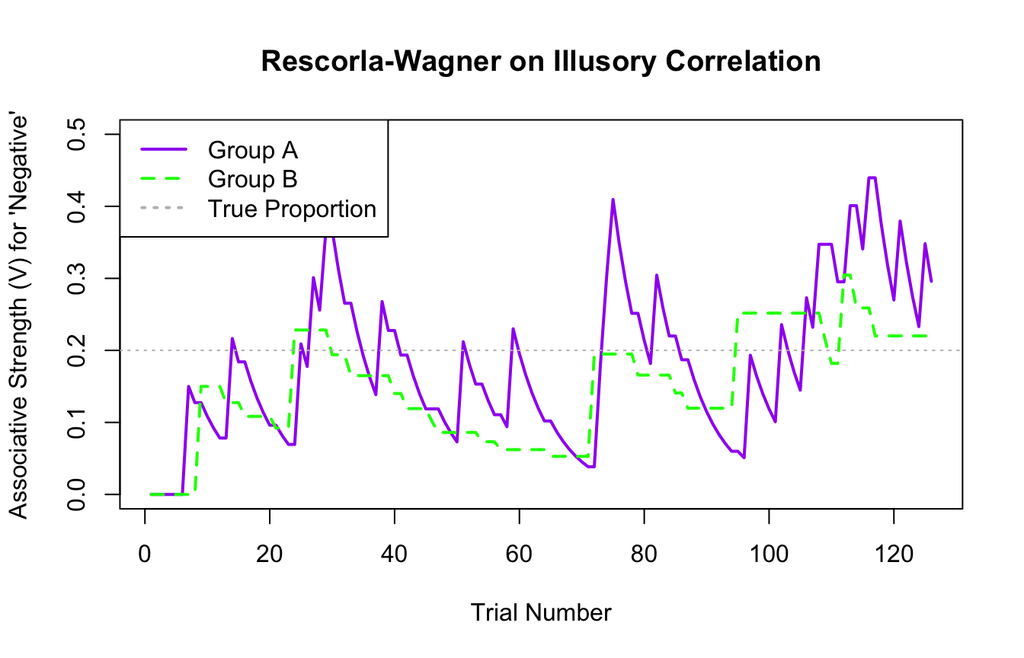

```r
# --- R-W Simulation ---
V_A <- 0 #Initial association between Group A and negative behaviors
V_B <- 0 #Initiol association between Group B and negative behaviors
alpha <- 0.3 #Salience of behaviors
beta <- 0.5 # Learning rate

# Store history containers
history_V_A <- c(0)
history_V_B <- c(0)

# Loop over trials
for (i in 1:nrow(shuffled_trials)) {
  trial <- shuffled_trials[i, ]

  if (trial$group == "A") {
    prediction_error <- trial$lambda - V_A
    delta_V <- alpha * beta * prediction_error
    V_A <- V_A + delta_V
  } else { # Group B trial
    prediction_error <- trial$lambda - V_B
    delta_V <- alpha * beta * prediction_error
    V_B <- V_B + delta_V
  }

  history_V_A <- c(history_V_A, V_A)
  history_V_B <- c(history_V_B, V_B)
}

# --- Plot R-W Results ---
plot(history_V_A, type="l", col="purple", lwd=2, ylim=c(0, 0.5),
     xlab="Trial Number", ylab="Associative Strength (V) for 'Negative'",
     main="Rescorla-Wagner on Illusory Correlation")
lines(history_V_B, type="l", col="green", lwd=2, lty=2)
abline(h = group_a_neg / (group_a_pos + group_a_neg), lty=3, col="gray")
legend("topleft", legend=c("Group A", "Group B", "True Proportion"),
       col=c("purple", "green", "gray"), lty=c(1, 2, 3), lwd=2)
```

```r
# --- Bayesian Simulation ---
# Prior beliefs for both groups (uninformative)
prior_a_A <- 1; prior_b_A <- 1
prior_a_B <- 1; prior_b_B <- 1

# --- Run through the trials ---
# We can just count the final outcomes for simplicity
final_counts <- aggregate(lambda ~ group, data=shuffled_trials, FUN=sum)
total_counts <- as.data.frame(table(shuffled_trials$group))
names(final_counts) <- c("group", "neg_behaviors")
final_counts$pos_behaviors <- total_counts$Freq - final_counts$neg_behaviors
show(final_counts)
```

```
##   group neg_behaviors pos_behaviors
## 1     A            20            80
## 2     B             5            20
```

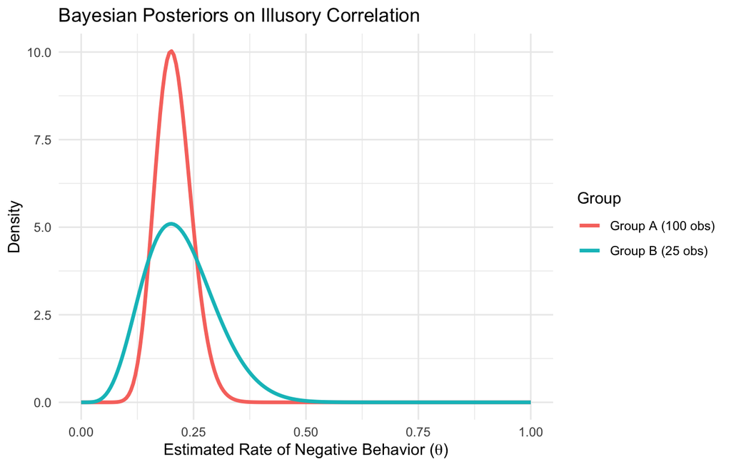

```r
# Update posteriors based on all data
posterior_a_A <- prior_a_A + final_counts$neg_behaviors[final_counts$group == "A"]
posterior_b_A <- prior_b_A + final_counts$pos_behaviors[final_counts$group == "A"]

posterior_a_B <- prior_a_B + final_counts$neg_behaviors[final_counts$group == "B"]
posterior_b_B <- prior_b_B + final_counts$pos_behaviors[final_counts$group == "B"]

# --- Plot Bayesian Results ---
theta <- seq(0, 1, length.out=200)
density_A <- dbeta(theta, posterior_a_A, posterior_b_A)
density_B <- dbeta(theta, posterior_a_B, posterior_b_B)

plot_data_bayes <- data.frame(
  theta = rep(theta, 2),
  density = c(density_A, density_B),
  Group = rep(c(paste0("Group A (", total_counts$Freq[1], " obs)"),
                paste0("Group B (", total_counts$Freq[2], " obs)")),
              each=200)
)

ggplot(plot_data_bayes, aes(x=theta, y=density, color=Group)) +
  geom_line(size=1.2) +
  labs(title="Bayesian Posteriors on Illusory Correlation",
       x=expression(paste("Estimated Rate of Negative Behavior (", theta,")")),
       y="Density") +
  theme_minimal()
```